# Chapter 6: Linear Model Selection and Regularization

Paulo Loyola

Carrega o pacote utilizado:

```r
library(ISLR)
```

**8)** **a)**

```r
set.seed(1)
X = rnorm(100)
epsilon = rnorm(100)
```

**b)**

```r
Y = 1 + 2*X + 3*X^2 + 4*X^3 + epsilon
```

**c)** Carrega o banco leaps, que possui a função regsubsets() usada para best subset selection:

```r
library(leaps)
```

Best subset selection:

```r
data = data.frame(Y, X)
bestsub = regsubsets(Y ~ poly(X, 10, raw = TRUE), data, nvmax = 10)
bestsub.summary = summary(bestsub)
bestsub.summary
```

```
## Subset selection object
## Call: regsubsets.formula(Y ~ poly(X, 10, raw = TRUE), data, nvmax = 10)
## 10 Variables  (and intercept)
##                           Forced in Forced out
## poly(X, 10, raw = TRUE)1      FALSE      FALSE
## poly(X, 10, raw = TRUE)2      FALSE      FALSE
## poly(X, 10, raw = TRUE)3      FALSE      FALSE
## poly(X, 10, raw = TRUE)4      FALSE      FALSE
## poly(X, 10, raw = TRUE)5      FALSE      FALSE
## poly(X, 10, raw = TRUE)6      FALSE      FALSE
## poly(X, 10, raw = TRUE)7      FALSE      FALSE
## poly(X, 10, raw = TRUE)8      FALSE      FALSE
## poly(X, 10, raw = TRUE)9      FALSE      FALSE
## poly(X, 10, raw = TRUE)10     FALSE      FALSE
## 1 subsets of each size up to 10
```

[output cut: 56 more lines]

```r
names(bestsub.summary)
```

```
## [1] "which"  "rsq"    "rss"    "adjr2"  "cp"     "bic"    "outmat" "obj"
```

Identificando o melhor modelo de acordo com $C_P$, $BIC$ e $Adjusted-R^2$:

```r
bestsub.summary$cp
```

```
##  [1] 1123.2892318  109.3256041    2.1859433    0.6067483    2.1782005
##  [6]    3.9955812    5.7869063    7.1694092    9.1535580   11.0000000
```

```r
bestsub.summary$bic
```

```
##  [1] -262.7744 -437.2907 -509.6393 -508.9084 -504.7773 -500.3748 -496.0018
##  [8] -492.0868 -487.4994 -483.0666
```

```r
bestsub.summary$adjr2
```

```
##  [1] 0.9334429 0.9887867 0.9947516 0.9948979 0.9948680 0.9948233 0.9947792
##  [8] 0.9947581 0.9947008 0.9946505
```

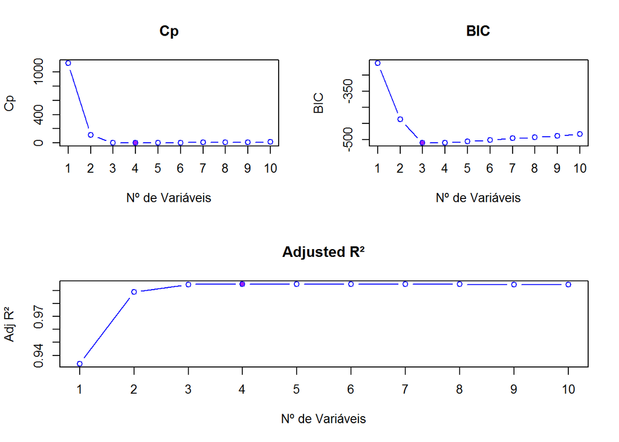

```r
layout(matrix(c(1,2,3,3), 2, 2, byrow = TRUE))
plot(bestsub.summary$cp ~ c(1:10), ylab = "Cp", xlab = "Nº de Variáveis", col = "blue", type = "b", main = "Cp", xaxt = "n")
axis(1, xaxp=c(0, 10, 10))
points(which.min(bestsub.summary$cp), bestsub.summary$cp[which.min(bestsub.summary$cp)], col = "purple", pch = 20)
plot(bestsub.summary$bic ~ c(1:10), ylab = "BIC", xlab = "Nº de Variáveis", col = "blue", type = "b", main = "BIC", xaxt = "n")
axis(1, xaxp=c(0, 10, 10))
points(which.min(bestsub.summary$bic), bestsub.summary$bic[which.min(bestsub.summary$bic)], col = "purple", pch = 20)
plot(bestsub.summary$adjr2 ~ c(1:10), ylab = "Adj R²", xlab = "Nº de Variáveis", col = "blue", type = "b", main = "Adjusted R²", xaxt = "n")
axis(1, xaxp=c(0, 10, 10))
points(which.max(bestsub.summary$adjr2), bestsub.summary$adjr2[which.max(bestsub.summary$adjr2)], col = "purple", pch = 20)
```

Há diferença pequena entre os modelos. Segundo o $C_p$ e o $Adjusted-R²$, o melhor modelo seria o modelo com 4 variáveis. Já para o $BIC$, o melhor modelo seria aquele com 3 variáveis. Comparando estes dois modelo, vemos que as diferenças nessas duas estatísticas não é grande de modo que parece ser mais adequado escolher o modelo com 3 variáveis, pois ele seria mais fácil de ser interpretado e não tem muita diferença em relação ao modelo de 4 variáveis. Vale destacar que os modelos com um número de variáveis entre 3 e 10 não apresentam muita diferença em suas estatísticas, novamente sugerindo que a melhor escolha entre esses modelos seria o modelo de 3 variáveis, por sua maior simplicidade em comparação com os demais.

Coeficientes do melhor Modelo (de 3 variáveis):

```r
coef(bestsub, 3)
```

```
##              (Intercept) poly(X, 10, raw = TRUE)1 poly(X, 10, raw = TRUE)2
##                 1.061507                 1.975280                 2.876209
## poly(X, 10, raw = TRUE)3
##                 4.017639
```

O melhor modelo é aquele com as 3 variáveis, da forma como foi criado em *b)*. Nota-se que os valores estimados para os $\beta's$ estão bem próximos daqueles que foram atribuídos no item anterior.

**d)** **Forward Stepwise Selection:**

```r
fselection = regsubsets(Y ~ poly(X, 10, raw = TRUE), data, nvmax = 10, method = "forward")
fselection.summary = summary(fselection)
fselection.summary
```

```
## Subset selection object
## Call: regsubsets.formula(Y ~ poly(X, 10, raw = TRUE), data, nvmax = 10,
##     method = "forward")
## 10 Variables  (and intercept)
##                           Forced in Forced out
## poly(X, 10, raw = TRUE)1      FALSE      FALSE
## poly(X, 10, raw = TRUE)2      FALSE      FALSE
## poly(X, 10, raw = TRUE)3      FALSE      FALSE
## poly(X, 10, raw = TRUE)4      FALSE      FALSE
## poly(X, 10, raw = TRUE)5      FALSE      FALSE
## poly(X, 10, raw = TRUE)6      FALSE      FALSE
## poly(X, 10, raw = TRUE)7      FALSE      FALSE
## poly(X, 10, raw = TRUE)8      FALSE      FALSE
## poly(X, 10, raw = TRUE)9      FALSE      FALSE
## poly(X, 10, raw = TRUE)10     FALSE      FALSE
```

[output cut: 57 more lines]

**Forward Stepwise Selection - $C_P$, $BIC$ e $Adjusted-R^2$:**

```r
fselection.summary$cp
```

```
##  [1] 1123.2892318  109.3256041    2.1859433    0.6067483    2.1782005
##  [6]    4.0621068    6.0165107    7.9582570    9.7842795   11.0000000
```

```r
fselection.summary$bic
```

```
##  [1] -262.7744 -437.2907 -509.6393 -508.9084 -504.7773 -500.3010 -495.7464
##  [8] -491.2060 -486.7944 -483.0666
```

```r
fselection.summary$adjr2
```

```
##  [1] 0.9334429 0.9887867 0.9947516 0.9948979 0.9948680 0.9948195 0.9947658
##  [8] 0.9947117 0.9946633 0.9946505
```

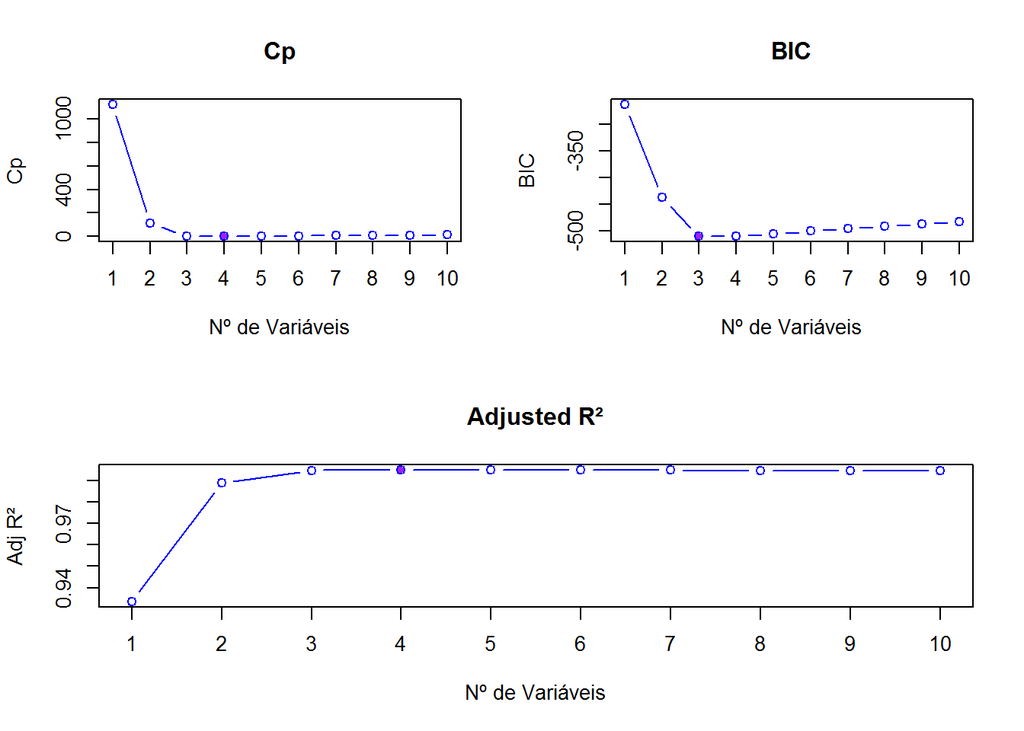

```r
layout(matrix(c(1,2,3,3), 2, 2, byrow = TRUE))
plot(fselection.summary$cp ~ c(1:10), ylab = "Cp", xlab = "Nº de Variáveis", col = "blue", type = "b", main = "Cp", xaxt = "n")
axis(1, xaxp=c(0, 10, 10))
points(which.min(fselection.summary$cp), fselection.summary$cp[which.min(fselection.summary$cp)], col = "purple", pch = 20)
plot(fselection.summary$bic ~ c(1:10), ylab = "BIC", xlab = "Nº de Variáveis", col = "blue", type = "b", main = "BIC", xaxt = "n")
axis(1, xaxp=c(0, 10, 10))
points(which.min(fselection.summary$bic), fselection.summary$bic[which.min(fselection.summary$bic)], col = "purple", pch = 20)
plot(fselection.summary$adjr2 ~ c(1:10), ylab = "Adj R²", xlab = "Nº de Variáveis", col = "blue", type = "b", main = "Adjusted R²", xaxt = "n")
axis(1, xaxp=c(0, 10, 10))
points(which.max(fselection.summary$adjr2), fselection.summary$adjr2[which.max(fselection.summary$adjr2)], col = "purple", pch = 20)
```

Coeficientes do melhor Modelo (de 3 variáveis):

```r
coef(fselection, 3)
```

```
##              (Intercept) poly(X, 10, raw = TRUE)1 poly(X, 10, raw = TRUE)2
##                 1.061507                 1.975280                 2.876209
## poly(X, 10, raw = TRUE)3
##                 4.017639
```

**Bacward Stepwise Selection**

```r
bselection = regsubsets(Y ~ poly(X, 10, raw = TRUE), data, nvmax = 10, method = "backward")
bselection.summary = summary(bselection)
bselection.summary
```

```
## Subset selection object
## Call: regsubsets.formula(Y ~ poly(X, 10, raw = TRUE), data, nvmax = 10,
##     method = "backward")
## 10 Variables  (and intercept)
##                           Forced in Forced out
## poly(X, 10, raw = TRUE)1      FALSE      FALSE
## poly(X, 10, raw = TRUE)2      FALSE      FALSE
## poly(X, 10, raw = TRUE)3      FALSE      FALSE
## poly(X, 10, raw = TRUE)4      FALSE      FALSE
## poly(X, 10, raw = TRUE)5      FALSE      FALSE
## poly(X, 10, raw = TRUE)6      FALSE      FALSE
## poly(X, 10, raw = TRUE)7      FALSE      FALSE
## poly(X, 10, raw = TRUE)8      FALSE      FALSE
## poly(X, 10, raw = TRUE)9      FALSE      FALSE
## poly(X, 10, raw = TRUE)10     FALSE      FALSE
```

[output cut: 57 more lines]

**Backward Stepwise Selection - $C_P$, $BIC$ e $Adjusted-R^2$:**

```r
bselection.summary$cp
```

```
##  [1] 1123.2892318  109.3256041    2.1859433    0.9808795    2.7310150
##  [6]    4.4181003    5.9250326    7.1694092    9.1535580   11.0000000
```

```r
bselection.summary$bic
```

```
##  [1] -262.7744 -437.2907 -509.6393 -508.4963 -504.1661 -499.9065 -495.8481
##  [8] -492.0868 -487.4994 -483.0666
```

```r
bselection.summary$adjr2
```

```
##  [1] 0.9334429 0.9887867 0.9947516 0.9948768 0.9948365 0.9947990 0.9947711
##  [8] 0.9947581 0.9947008 0.9946505
```

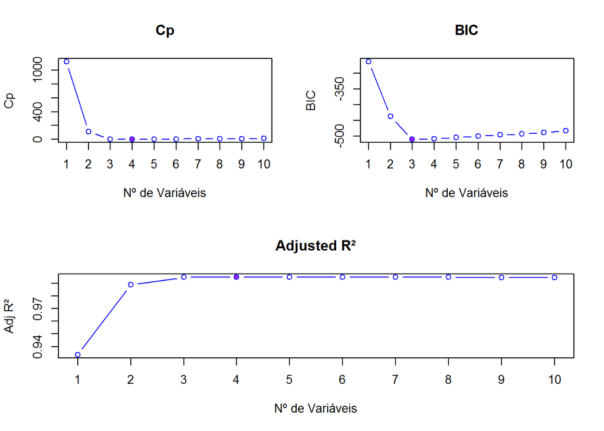

```r
layout(matrix(c(1,2,3,3), 2, 2, byrow = TRUE))
plot(bselection.summary$cp ~ c(1:10), ylab = "Cp", xlab = "Nº de Variáveis", col = "blue", type = "b", main = "Cp", xaxt = "n")
axis(1, xaxp=c(0, 10, 10))
points(which.min(bselection.summary$cp), bselection.summary$cp[which.min(bselection.summary$cp)], col = "purple", pch = 20)
plot(bselection.summary$bic ~ c(1:10), ylab = "BIC", xlab = "Nº de Variáveis", col = "blue", type = "b", main = "BIC", xaxt = "n")
axis(1, xaxp=c(0, 10, 10))
points(which.min(bselection.summary$bic), bselection.summary$bic[which.min(bselection.summary$bic)], col = "purple", pch = 20)
plot(bselection.summary$adjr2 ~ c(1:10), ylab = "Adj R²", xlab = "Nº de Variáveis", col = "blue", type = "b", main = "Adjusted R²", xaxt = "n")
axis(1, xaxp=c(0, 10, 10))
points(which.max(bselection.summary$adjr2), bselection.summary$adjr2[which.max(bselection.summary$adjr2)], col = "purple", pch = 20)
```

Coeficientes do melhor Modelo (de 3 variáveis):

```r
coef(bselection, 3)
```

```
##              (Intercept) poly(X, 10, raw = TRUE)1 poly(X, 10, raw = TRUE)2
##                 1.061507                 1.975280                 2.876209
## poly(X, 10, raw = TRUE)3
##                 4.017639
```

No caso deste modelo, usar *Forward Stepwise Selection* e *Backward Stepwise Selection* trouxe os mesmos resultados que usar *Best Subset Selection*.

**e)** Carrega a biblioteca para utilizar o Lasso:

```r
library(glmnet)
```

Obtém o melhor lambda para o Modelo:

```r
xmatrix = model.matrix(Y ~ poly(X, 10, raw = T), data)[, -1]
model.lasso = cv.glmnet(xmatrix, Y, alpha = 1)
best.lambda = model.lasso$lambda.min
best.lambda
```

```
## [1] 0.07660225
```

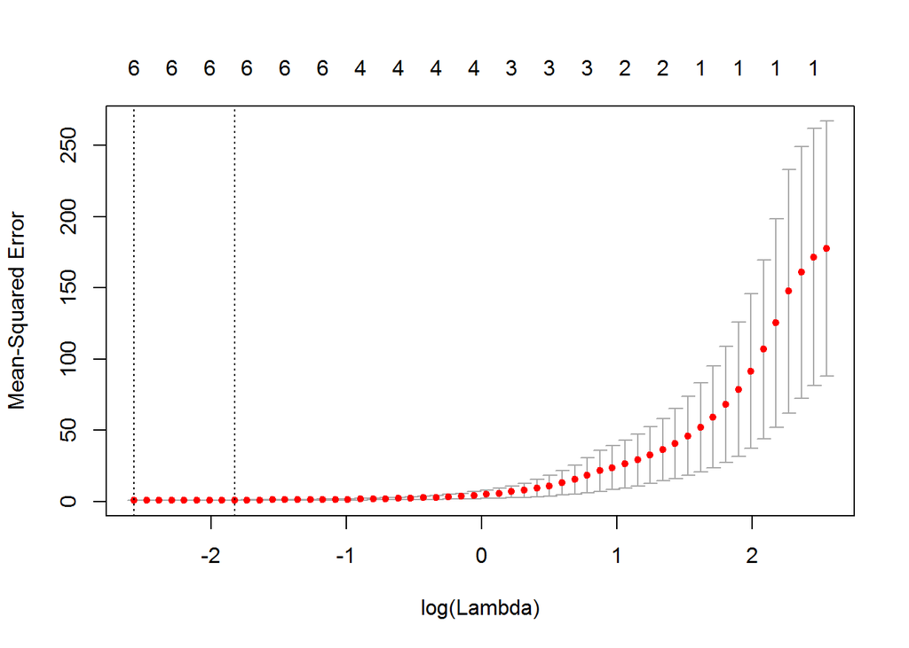

```r
plot(model.lasso)
```

Modelo Lasso com o lambda obtido anteriorment:

```r
best.lasso = glmnet(xmatrix, Y, alpha = 1)
predict(best.lasso, s = best.lambda, type = "coefficients")
```

```
## 11 x 1 sparse Matrix of class "dgCMatrix"
##                                  1
## (Intercept)            1.182646169
## poly(X, 10, raw = T)1  2.137739131
## poly(X, 10, raw = T)2  2.623547995
## poly(X, 10, raw = T)3  3.813195738
## poly(X, 10, raw = T)4  0.042303133
## poly(X, 10, raw = T)5  0.012404464
## poly(X, 10, raw = T)6  .
## poly(X, 10, raw = T)7  0.003849104
## poly(X, 10, raw = T)8  .
## poly(X, 10, raw = T)9  .
## poly(X, 10, raw = T)10 .
```

O Melhor modelo, segundo o Lasso, também inclui as variáveis X4, X5 e X7.

**f)** Gerando o novo $Y = \beta_0+\beta_7X^7 + \epsilon$:

```r
Y = 1 + 8 * X^7 + epsilon
data2 = data.frame(Y, X)
```

** Best Subset Selection **

```r
bestsub = regsubsets(Y ~ poly(X, 10, raw = TRUE), data2, nvmax = 10)
bestsub.summary = summary(bestsub)
bestsub.summary
```

```
## Subset selection object
## Call: regsubsets.formula(Y ~ poly(X, 10, raw = TRUE), data2, nvmax = 10)
## 10 Variables  (and intercept)
##                           Forced in Forced out
## poly(X, 10, raw = TRUE)1      FALSE      FALSE
## poly(X, 10, raw = TRUE)2      FALSE      FALSE
## poly(X, 10, raw = TRUE)3      FALSE      FALSE
## poly(X, 10, raw = TRUE)4      FALSE      FALSE
## poly(X, 10, raw = TRUE)5      FALSE      FALSE
## poly(X, 10, raw = TRUE)6      FALSE      FALSE
## poly(X, 10, raw = TRUE)7      FALSE      FALSE
## poly(X, 10, raw = TRUE)8      FALSE      FALSE
## poly(X, 10, raw = TRUE)9      FALSE      FALSE
## poly(X, 10, raw = TRUE)10     FALSE      FALSE
## 1 subsets of each size up to 10
```

[output cut: 56 more lines]

Identificando o melhor modelo de acordo com $C_P$, $BIC$ e $Adjusted-R^2$:

```r
bestsub.summary$cp
```

```
##  [1] -0.05835158 -0.57457577 -0.26264076  0.73888307  2.40063344
##  [6]  3.84493124  5.81405698  7.18226563  9.16504068 11.00000000
```

```r
bestsub.summary$bic
```

```
##  [1] -1237.438 -1235.491 -1232.709 -1229.198 -1224.966 -1220.978 -1216.407
##  [8] -1212.508 -1207.922 -1203.502
```

```r
bestsub.summary$adjr2
```

```
##  [1] 0.9999961 0.9999962 0.9999962 0.9999962 0.9999962 0.9999962 0.9999961
##  [8] 0.9999961 0.9999961 0.9999960
```

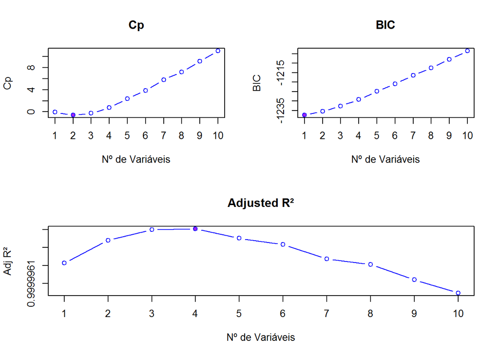

```r
layout(matrix(c(1,2,3,3), 2, 2, byrow = TRUE))
plot(bestsub.summary$cp ~ c(1:10), ylab = "Cp", xlab = "Nº de Variáveis", col = "blue", type = "b", main = "Cp", xaxt = "n")
axis(1, xaxp=c(0, 10, 10))
points(which.min(bestsub.summary$cp), bestsub.summary$cp[which.min(bestsub.summary$cp)], col = "purple", pch = 20)
plot(bestsub.summary$bic ~ c(1:10), ylab = "BIC", xlab = "Nº de Variáveis", col = "blue", type = "b", main = "BIC", xaxt = "n")
axis(1, xaxp=c(0, 10, 10))
points(which.min(bestsub.summary$bic), bestsub.summary$bic[which.min(bestsub.summary$bic)], col = "purple", pch = 20)
plot(bestsub.summary$adjr2 ~ c(1:10), ylab = "Adj R²", xlab = "Nº de Variáveis", col = "blue", type = "b", main = "Adjusted R²", xaxt = "n")
axis(1, xaxp=c(0, 10, 10))
points(which.max(bestsub.summary$adjr2), bestsub.summary$adjr2[which.max(bestsub.summary$adjr2)], col = "purple", pch = 20)
```

Coeficientes das variáveis identificadas por cada um dos modelos:

```r
coef(bestsub, 1)
```

```
##              (Intercept) poly(X, 10, raw = TRUE)7
##                0.9589402                8.0007705
```

```r
coef(bestsub, 2)
```

```
##              (Intercept) poly(X, 10, raw = TRUE)2 poly(X, 10, raw = TRUE)7
##                1.0704904               -0.1417084                8.0015552
```

```r
coef(bestsub, 4)
```

```
##              (Intercept) poly(X, 10, raw = TRUE)1 poly(X, 10, raw = TRUE)2
##                1.0762524                0.2914016               -0.1617671
## poly(X, 10, raw = TRUE)3 poly(X, 10, raw = TRUE)7
##               -0.2526527                8.0091338
```

Observa-se que o $BIC$ foi a estatística que conseguiu identificar o melhor modelo com maior sucesso - identificando corretamente os valores de $\beta_0$ e $\beta_7$, assim como que Y tem apenas um intercepto e uma variável $X$ elevada à sétima potência. Vale destacar que o $Adjusted-R^2$ identifica o modelo com 4 variáveis como o melhor modelo, mas a diferença entre os modelos aparece apenas na sétima casa decimal, de acordo com esta estatística.

** LASSO ** Obtém o melhor lambda para o novo Modelo:

```r
xmatrix = model.matrix(Y ~ poly(X, 10, raw = T), data2)[, -1]
model.lasso = cv.glmnet(xmatrix, Y, alpha = 1)
best.lambda = model.lasso$lambda.min
best.lambda
```

```
## [1] 15.51383
```

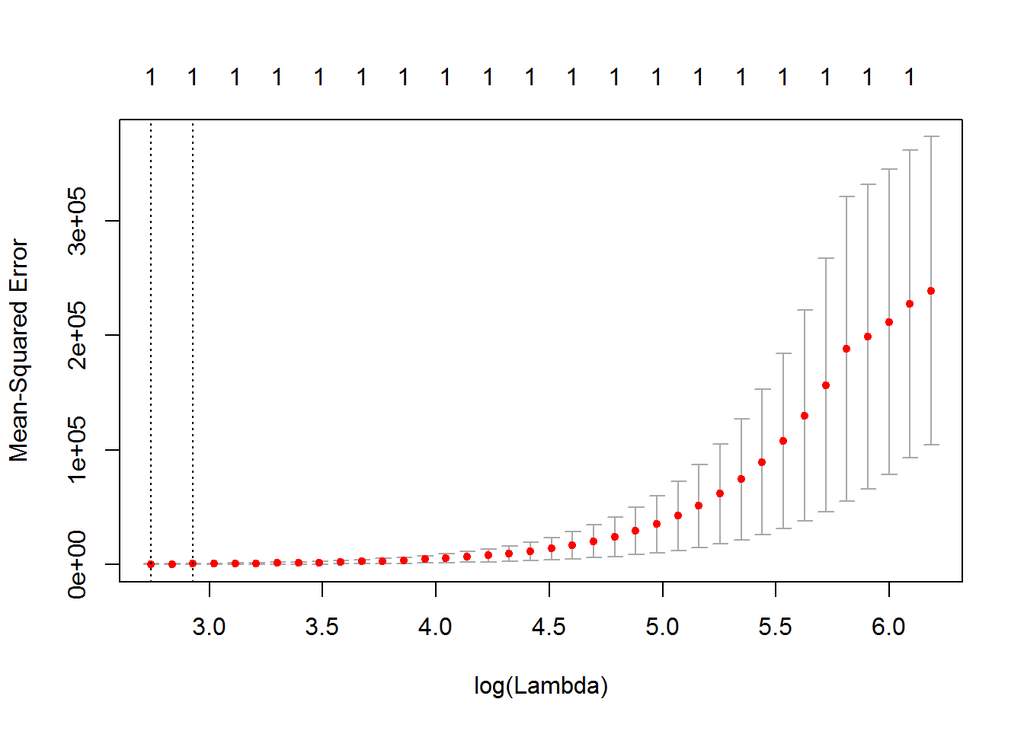

```r
plot(model.lasso)
```

Modelo Lasso com o melhor lambda obtido por cross validation:

```r
best.lasso = glmnet(xmatrix, Y, alpha = 1)
predict(best.lasso, s = best.lambda, type = "coefficients")
```

```
## 11 x 1 sparse Matrix of class "dgCMatrix"
##                               1
## (Intercept)            2.039208
## poly(X, 10, raw = T)1  .
## poly(X, 10, raw = T)2  .
## poly(X, 10, raw = T)3  .
## poly(X, 10, raw = T)4  .
## poly(X, 10, raw = T)5  .
## poly(X, 10, raw = T)6  .
## poly(X, 10, raw = T)7  7.744804
## poly(X, 10, raw = T)8  .
## poly(X, 10, raw = T)9  .
## poly(X, 10, raw = T)10 .
```

O Lasso identifica corretamente que o melhor Modelo tem apenas o intercepto e $\beta_7X^7$, apesar de ter um erro um pouco maior em relação ao intercepto.

**9)** **a)** Divide o banco College em train e test:

```r
set.seed(1)
train = sample(nrow(College), nrow(College)/2)
test = College[-train,]
train = College[train,]
```

**b)** OLS no banco train com test error:

```r
OLS = lm(Apps ~., train)
OLSpred = predict(OLS, test)
mean((test[,"Apps"] - OLSpred)^2)
```

```
## [1] 1108531
```

**c)** Ridge Regression no banco train com lambda escolhido por cross-validation e test error:

```r
train.matrix = model.matrix(Apps ~ ., data = train)
test.matrix = model.matrix(Apps ~ ., data = test)
grid = 10 ^ seq(4, -2, length = 100)
ridge = cv.glmnet(train.matrix, train[, "Apps"], alpha=0, lambda=grid, thresh=1e-12)
best.lambda = ridge$lambda.min
best.lambda
```

```
## [1] 0.01149757
```

```r
ridgepred = predict(ridge, newx = test.matrix, s = best.lambda)
mean((test[,"Apps"] - ridgepred)^2)
```

```
## [1] 1108512
```

O test error obtido é bem próximo daquele obtido com o modelo de OLS, entretanto este é marginalmente menor.

**d)** Lasso no banco train com lambda escolhido por cross-validation e test error:

```r
lasso = cv.glmnet(train.matrix, train[,"Apps"], alpha = 1, lambda=grid, thresh=1e-12)
best.lambda = model.lasso$lambda.min
lassopred = predict(lasso, newx = test.matrix, s = best.lambda)
mean((test[,"Apps"] - lassopred)^2)
```

```
## [1] 1052370
```

O test error do Lasso é menor que aqueles dos modelos anteriores, sugerindo que o lasso fornece um modelo melhor para a análise desses dados que os modelos anteriores.  
Coeficientes do Modelo:

```r
lasso = glmnet(model.matrix(Apps~., data=College), College[,"Apps"], alpha=1)
predict(lasso, s = best.lambda, type = "coefficients")
```

```
## 19 x 1 sparse Matrix of class "dgCMatrix"
##                         1
## (Intercept) -5.636282e+02
## (Intercept)  .
## PrivateYes  -4.521544e+02
## Accept       1.491358e+00
## Enroll      -3.167059e-01
## Top10perc    3.811741e+01
## Top25perc   -5.484458e+00
## F.Undergrad  .
## P.Undergrad  3.155951e-02
## Outstate    -6.626178e-02
## Room.Board   1.329996e-01
## Books        .
## Personal     9.027901e-03
## PhD         -6.514899e+00
## Terminal    -3.188327e+00
## S.F.Ratio    7.860181e+00
## perc.alumni -7.727723e-01
## Expend       7.199130e-02
## Grad.Rate    6.078399e+00
```

**e)** PCR no banco train com M escolhido por cross-validation e test error.  
Carrega o pacote para usar PCR:

```r
library(pls)
```

** Principal Components Regression **

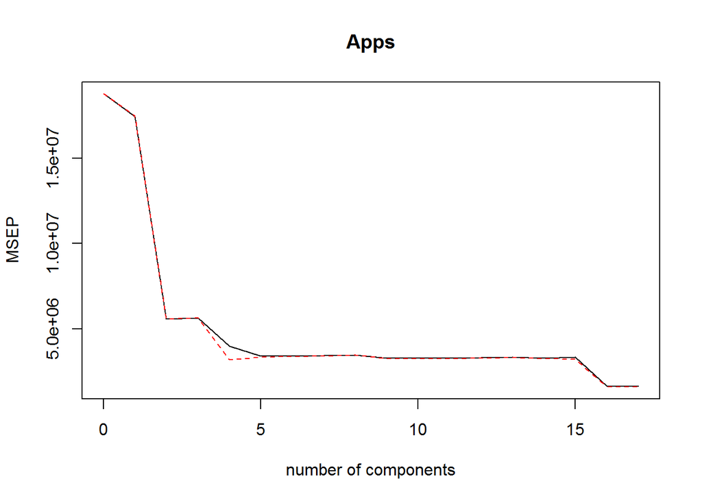

```r
set.seed(1)
pcreg = pcr(Apps ~ ., data = train, scale=T, validation="CV")
validationplot(pcreg, val.type = "MSEP")
```

```r
pcreg.pred = predict(pcreg, test, ncomp=10)
mean((test[, "Apps"] - data.frame(pcreg.pred))^2)
```

```
## [1] NA
```

**f)** PLS no banco train com M escolhido por cross-validation e test error:

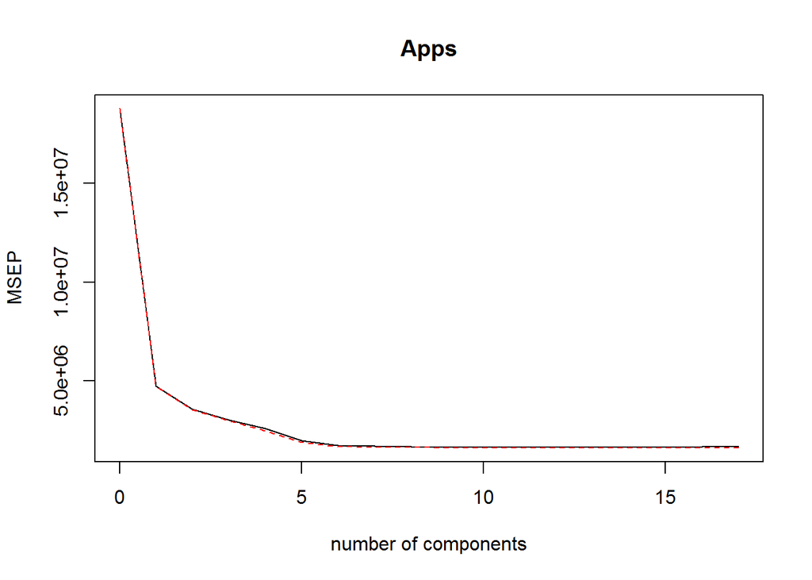

```r
plsfit = plsr(Apps ~ ., data = train, scale=T, validation="CV")
validationplot(plsfit, val.type = "MSEP")
```

```r
plspred = predict(plsfit, test, ncomp=10)
mean((test[, "Apps"] - data.frame(plspred))^2)
```

```
## [1] NA
```

**10)** **a)**